# ECOM30004/90004 Time Series Analysis and Forecasting Tutorial 10 Tutor: Pengyun (Kevin) Chen University of Melbourne Semester 2, 2026

## Notice

**Conditions of Use**

- This document is intended for personal use and is NOT meant to be shared on the internet (e.g. Studocu, ThinkSwap, StudentVIP, Coursehero, etc.)
- Do not share this document with anyone, even if they are enrolled in ECOM30004/90004.
- Official course materials, such as lecture slides, tutorial sheets and prescribed readings should always be your primary point of reference.
- Slides accessible here: `pengyunc.github.io/TSAF_Week10`
- Download HTML versions here: [Dropbox Link](https://www.dropbox.com/scl/fo/aoxoud5ex0j42hsrod3dg/ADblAt_jJ9hpESZME9FDcWc?rlkey=0s0oyf1y3uokzvlhbzxe2yy3g&st=kx2yupzr&dl=0)

## This tutorial: Prediction Interval Estimation

In this tutorial we use simulation to understand and explore the methods for prediction interval calculation.

**Activities**

- Exercises 1 & 2: Simulating 95% prediction intervals — coverage and average length (width)
- Exercise 3: Investigating the effect of model misspecification on prediction interval properties
- Exercise 4: Simulating prediction intervals with non-normal disturbances

## Recap: Prediction Intervals

- Consider an AR(1) model and assume $Y_{n+1}$ has conditional distribution:
  $$Y_{n+1} = \phi_{1}Y_{n} + U_{n+1}
  \quad \text{and} \quad
  Y_{n+1}\mid \mathscr{Y}_{t} \sim \mathrm{N}(\phi_{1}Y_{n}, \sigma_{n}^{2})$$
  $$\color{blue}{\implies\quad \sigma_{n}^{2}=\operatorname{var}(Y_{n+1}\mid\mathscr{Y}_{n})
  = \operatorname{var}(U_{n+1}\mid\mathscr{Y}_{n})}$$
  where $U_{t+1}$ is the 1-step-ahead prediction error.
- The 95% confidence interval for $(Y_{n+1}\mid\mathscr{Y}_{n})$ is:
  $$\phi_{1}Y_{n}\pm 1.96\times \sigma_{n}$$
- It follows that the 95% prediction interval for $Y_{n+1}$ is:
  $$\quad\quad\color{purple}{\hat{\phi}_{1}}Y_{t}\color{black}{\,\pm\, 1.96\times\,}\color{teal}{\hat{\sigma}_{n}}\color{black}\quad\textsf{where}\quad \begin{aligned}\color{purple}{\hat{\phi}_{1}}&\color{purple}{\textsf{ is the usual parameter estimate}}\\
  \color{teal}{\hat{\sigma}^{2}_{n}}&\color{teal}{=\frac{1}{n}\sum^{n}_{t=2}\hat{U}_{t}^{2}}\end{aligned}$$
  assuming $\operatorname{var}(U_{t}\mid\mathscr{Y}_{t-1})$ is constant for all $t$.

## Recap: Prediction Intervals

- It follows that the 95% prediction interval for $Y_{n+1}$ is:
  $$\quad\quad\color{purple}{\hat{\phi}_{1}}Y_{n}\color{black}{\,\pm\, 1.96\times\,}\color{teal}{\hat{\sigma}_{n}}\color{black}\quad\textsf{where}\quad \begin{aligned}\color{purple}{\hat{\phi}_{1}}&\color{purple}{\textsf{ is the usual parameter estimate}}\\
  \color{teal}{\hat{\sigma}^{2}_{n}}&\color{teal}{=\frac{1}{n}\sum^{n}_{t=2}\hat{U}_{t}^{2}}\end{aligned}$$
  assuming $\operatorname{var}(U_{t}\mid\mathscr{Y}_{t-1})$ is constant for all $t$.
- This prediction interval contains $Y_{n+1}$ with approximately 95% probability in repeated samples. $\to$ we will illustrate this with a simulation
- This probability is understood in the frequentist sense:
  - given repeated drawings from the “population” of the data, the proportion of the constructed intervals will include actual $Y_t$ is 95%.
- Precision: A narrower prediction interval indicates a more precise forecast.

## Exercises 1 and 2

Simulate the 95% prediction intervals for $Y_{t+h}$ for $h=1,\dots,12$ for the AR process:
$$Y_{t}=0.8Y_{t-1}+U_{t}\quad\text{where}\quad U_{t}\sim\mathrm{N}(0,1)$$
Include in the simulation a calculation for the average length of the PIs for each $h$.

**Code Outline**

- Repeat the following experiment `reps=1000` times:
  - Generate $200+12$ draws of $U_t$ from $\mathrm{N}(0,1)$
  - Simulate $200+12$ observations from the AR(1) process
  - Withhold the final 12 observations as test set
  - Estimate the AR(1) model with the training set
  - Compute and store the upper and lower bounds of 95% PI for $h=1,2,\dots,12$
  - Check whether the true values are contained within the 95% PIs
- **Exercise 1:** Compute the probability at which the 95% PIs contains the true $Y_{t+h}$ for $h=1,2,\dots,12$
- **Exercise 2:** Compute the average lengths of the 95% PIs for each $h=1,2,\dots,12$

## Exercises 1 and 2

Simulate the 95% prediction intervals for $Y_{t+h}$ for $h=1,\dots,12$ for the AR process:
$$Y_{t}=0.8Y_{t-1}+U_{t}\quad\text{where}\quad U_{t}\sim\mathrm{N}(0,1)$$
Include in the simulation a calculation for the average length of the PIs for each $h$.

- Initialisation
- Simulation
- Extracting PIs Explained
- Results

```r
library(forecast)

set.seed(30004)       # For reproducibility

reps <- 1000
n <- 200              # Estimation sample size per experiment
hmax <- 12            # Forecast horizon
ar <- 0.8             # AR(1) true coefficient

# Storage for inclusion indicators
Included <- matrix(nrow=reps, ncol=hmax)

# Storage for length of each interval
Length <- matrix(nrow=reps, ncol=hmax)
```

```r
for (r in 1:reps){
  U <- rnorm(n+hmax)          # N(0,1) prediction errors
  Y <- arima.sim(n=n+hmax, model=list(ar=ar), innov=U)  # Simulate data
  Yf <- Y[(n+1):(n+hmax)]     # Forecast sample
  Y <- Y[1:n]                 # Estimation sample

  # Estimate AR(1) model and generate forecasts and PIs
  eq <- Arima(Y, order=c(1,0,0))
  eqf <- forecast(eq, h=hmax)

  Lower <- eqf$lower[,"95%"]       # lower bound of 95% PIs
  Upper <- eqf$upper[,"95%"]       # upper bound of 95% PIs

  Included[r,] <- 1*(Lower<Yf & Upper>Yf)     # Check inclusion
  Length[r,] <- Upper-Lower                   # Lengths of PIs
}
```

```r
eqf <- forecast(eq, h=hmax)
print(eqf)
```

```
    Point Forecast       Lo 80    Hi 80      Lo 95    Hi 95
201     1.28083447  0.04063708 2.521032 -0.6158838 3.177553
202     0.92003622 -0.64180357 2.481876 -1.4685916 3.308664
203     0.64385306 -1.07877267 2.366479 -1.9906756 3.278382
204     0.43244089 -1.37777477 2.242657 -2.3360451 3.200927
205     0.27060950 -1.58901411 2.130233 -2.5734394 3.114658
206     0.14673111 -1.74124272 2.034705 -2.7406757 3.034138
207     0.05190492 -1.85248483 1.956295 -2.8606079 2.964418
208    -0.02068246 -1.93462581 1.893261 -2.9478062 2.906441
209    -0.07624651 -1.99576576 1.843273 -3.0118979 2.859405
210    -0.11877958 -2.04155854 1.803999 -3.0594162 2.821857
211    -0.15133771 -2.07602417 1.773349 -3.0948916 2.792216
212    -0.17626025 -2.10206353 1.749543 -3.1215222 2.769002
```

```r
# Extract the lower bounds for 95% PI for h=1,2,...,12
print(eqf$lower)  # eqf$lower[,"95%"]
```

```
Time Series:
Start = 201
End = 212
Frequency = 1
            80%        95%
201  0.04063708 -0.6158838
202 -0.64180357 -1.4685916
203 -1.07877267 -1.9906756
204 -1.37777477 -2.3360451
205 -1.58901411 -2.5734394
206 -1.74124272 -2.7406757
207 -1.85248483 -2.8606079
208 -1.93462581 -2.9478062
209 -1.99576576 -3.0118979
210 -2.04155854 -3.0594162
211 -2.07602417 -3.0948916
212 -2.10206353 -3.1215222
```

```r
# Record 1 if true value contained within 95% PI, 0 otherwise
print(head(Included))
```

```
     [,1] [,2] [,3] [,4] [,5] [,6] [,7] [,8] [,9] [,10] [,11] [,12]
[1,]    1    1    1    1    1    1    1    1    1     1     1     1
[2,]    1    1    1    1    1    1    1    1    1     1     1     1
[3,]    1    1    1    1    1    1    1    1    1     1     1     1
[4,]    1    1    1    1    1    1    1    1    1     1     1     1
[5,]    1    1    1    1    1    1    1    1    1     1     1     1
[6,]    1    1    1    1    1    1    1    1    1     1     1     1
```

```r
# Recorded as difference between upper and lower bounds of 95% PI
print(head(Length))
```

```
         [,1]     [,2]     [,3]     [,4]     [,5]     [,6]     [,7]     [,8]
[1,] 3.973520 5.081556 5.674337 6.020780 6.230933 6.360872 6.442082 6.493161
[2,] 3.411552 4.056556 4.295261 4.390259 4.428980 4.444907 4.451482 4.454201
[3,] 3.689790 4.601810 5.037556 5.264030 5.385710 5.452124 5.488666 5.508858
[4,] 3.624406 4.682773 5.273785 5.634822 5.864058 6.012603 6.110006 6.174339
[5,] 3.510856 4.528788 5.093474 5.436087 5.652101 5.791073 5.881528 5.940824
[6,] 3.802634 4.982272 5.678894 6.129630 6.433261 6.642330 6.788202 6.890845
         [,9]    [,10]    [,11]    [,12]
[1,] 6.525413 6.545825 6.558763 6.566972
[2,] 4.455325 4.455791 4.455983 4.456063
[3,] 5.520042 5.526244 5.529686 5.531597
[4,] 6.217025 6.245431 6.264371 6.277016
[5,] 5.979868 6.005651 6.022709 6.034007
[6,] 6.963475 7.015064 7.051803 7.078016
```

## Exercises 1 and 2

Simulate the 95% prediction intervals for $Y_{t+h}$ for $h=1,\dots,12$ for the AR process:
$$Y_{t}=0.8Y_{t-1}+U_{t}\quad\text{where}\quad U_{t}\sim\mathrm{N}(0,1)$$
Include in the simulation a calculation for the average length of the PIs for each $h$.

- Exercise 1 - Coverage
- Exercise 2 - Lengths

Compute the probabilities at which the 95% PIs contains the true $Y_{t+h}$ for $h=1,\dots,12$.

```r
Coverage <- apply(Included, 2, mean) * 100
names(Coverage) <- paste0("h=", 1:hmax)
print(Coverage)
```

```
 h=1  h=2  h=3  h=4  h=5  h=6  h=7  h=8  h=9 h=10 h=11 h=12
94.4 93.3 94.7 93.5 92.9 92.3 94.4 93.9 94.7 93.9 93.5 93.2
```

The simulated coverages are slightly below 95%?

- arises partly because of simulation error (only 1000 simulations)
- also partly because the forecast intervals are based on model estimates from $n=200$ sample sizes which do not yield the exact model coefficients.

Compute the average lengths of the 95% PIs for each $h=1,2,\dots,12$.

```r
AvgLength <- round(apply(Length, 2, mean), 2)
names(AvgLength) <- paste0("h=", 1:hmax)
print(AvgLength)
```

```
 h=1  h=2  h=3  h=4  h=5  h=6  h=7  h=8  h=9 h=10 h=11 h=12
3.92 4.98 5.54 5.87 6.06 6.19 6.26 6.31 6.35 6.37 6.38 6.39
```

- The average length of the interval is increasing in $h$, which reflects the formula we have seen in lectures for the variances for $h$-step-ahead forecasts.
  $$\textstyle\operatorname{var}(U_{t\mid t-h})=\sum^{h-1}_{j=0}\phi_{1}^{2j}\sigma^{2}\qquad\color{teal}{\boxed{\leftarrow\;\textsf{\small{}From Lecture 9}\;}}$$
- Intuition: it is *more difficult* to forecast further into the future.

## Exercise 3

Now change the simulation to demonstrate the effects of model misspecification on the properties of the prediction intervals. $\to$ **Simulate AR(1) data, but forecast with MA(1)**

What are the implications for the prediction intervals? Explain the results for the lengths of the prediction intervals for $h>1$.

- Initialisation Code
- Estimation Code
- Results: Coverage
- Results: Lengths

Code for initialisation is the same as in Exercises 1 and 2.

```r
set.seed(30004)       # For reproducibility

reps <- 1000
n <- 200              # Estimation sample size per experiment
hmax <- 12            # Forecast horizon
ar <- 0.8             # AR(1) true coefficient

# Storage for inclusion indicators
Included <- matrix(nrow=reps, ncol=hmax)

# Storage for length of each interval
Length <- matrix(nrow=reps, ncol=hmax)
```

The only change is to the estimation command, replacing AR(1) with MA(1).

```r
for (r in 1:reps){
  U <- rnorm(n+hmax)          # N(0,1) prediction errors
  Y <- arima.sim(n=n+hmax, model=list(ar=ar), innov=U)  # Simulate data
  Yf <- Y[(n+1):(n+hmax)]     # Forecast sample
  Y <- Y[1:n]                 # Estimation sample

  # Estimate MA(1) model and generate forecasts and PIs
  eq <- Arima(Y, order=c(0,0,1))   ### <- MISSPECIFIED!!!
  eqf <- forecast(eq, h=hmax)

  Lower <- eqf$lower[,"95%"]       # lower bound of 95% PIs
  Upper <- eqf$upper[,"95%"]       # upper bound of 95% PIs

  Included[r,] <- 1*(Lower<Yf & Upper>Yf)     # Check inclusion
  Length[r,] <- Upper-Lower                   # Lengths of PIs
}
```

```r
# Coverage: proportion of inclusion at each h
Coverage <- apply(Included, 2, mean)*100
names(Coverage) <- paste0("h=",1:hmax)
print(Coverage)
```

```
 h=1  h=2  h=3  h=4  h=5  h=6  h=7  h=8  h=9 h=10 h=11 h=12
93.0 89.6 89.8 89.6 89.1 89.2 90.9 89.6 90.3 89.9 89.5 89.2
```

When the model is misspecified:

```r
# Average interval lengths:
AvgLength <- round(apply(Length, 2, mean),2)
names(AvgLength) <- paste0("h=",1:hmax)
print(AvgLength)
```

```
 h=1  h=2  h=3  h=4  h=5  h=6  h=7  h=8  h=9 h=10 h=11 h=12
4.76 5.65 5.65 5.65 5.65 5.65 5.65 5.65 5.65 5.65 5.65 5.65
```

The average lengths of the 95% PIs are the same for $h=2,\dots,12$.

## Exercise 3

**What’s going on?**

```
 h=1  h=2  h=3  h=4  h=5  h=6  h=7  h=8  h=9 h=10 h=11 h=12
4.76 5.65 5.65 5.65 5.65 5.65 5.65 5.65 5.65 5.65 5.65 5.65
```

Consider the MA(1) model: for any $t$ we have
$$Y_{t}=U_{t}+\theta_{1}U_{t-1}\quad\text{where}\quad U_{t}\sim\mathrm{N}(0,\sigma^{2})$$
To compute the 95% PI for $Y_{t+h}$, we need to know the distribution for $Y_{t+h}\mid\mathscr{Y}_{t}.$

When $h=1$:
$$Y_{t+1}=U_{t+1}+\theta_{1}U_{t}$$

$$\implies\quad \mathbb{E}(Y_{t+1}\mid\mathscr{Y}_{t})=\underbrace{\mathbb{E}(U_{t+1}\mid\mathscr{Y}_{t})}_{=\mathbb{E}(U_{t+1})=0}+\theta_{1}\underbrace{\mathbb{E}(U_{t}\mid\mathscr{Y}_{t})}_{=u_t}$$

$$\implies\quad \mathbb{E}(Y_{t+1}\mid\mathscr{Y}_{t})=\theta_{1}u_{t}$$
where $u_{t}$ is the realised value of $U_t$ (it is a constant).

## Exercise 3

**What’s going on?**

```
 h=1  h=2  h=3  h=4  h=5  h=6  h=7  h=8  h=9 h=10 h=11 h=12
4.76 5.65 5.65 5.65 5.65 5.65 5.65 5.65 5.65 5.65 5.65 5.65
```

Consider the MA(1) model: for any $t$ we have
$$Y_{t}=U_{t}+\theta_{1}U_{t-1}\quad\text{where}\quad U_{t}\sim\mathrm{N}(0,\sigma^{2})$$
To compute the 95% PI for $Y_{t+h}$, we need to know the distribution for $Y_{t+h}\mid\mathscr{Y}_{t}.$

When $h=1$:

Mean of $Y_{t+1}\mid\mathscr{Y}_{t}$: $\mathbb{E}(Y_{t+1}\mid\mathscr{Y}_{t})=\theta_{1}u_{t}$.

How about the variance?

$\displaystyle\operatorname{var}(Y_{t+1}\mid\mathscr{Y}_{t})=\underbrace{\operatorname{var}(U_{t+1}\mid\mathscr{Y}_{t})}_{=\operatorname{var}(U_{t+1})=\sigma^{2}}+\underbrace{\;\;\operatorname{var}(\theta_{1}U_{t}\mid\mathscr{Y}_{t})\;\;}_{=0,\; \theta_{1}u_{t}\text{ is a constant}}$$=\sigma^{2}$

## Exercise 3

**What’s going on?**

```
 h=1  h=2  h=3  h=4  h=5  h=6  h=7  h=8  h=9 h=10 h=11 h=12
4.76 5.65 5.65 5.65 5.65 5.65 5.65 5.65 5.65 5.65 5.65 5.65
```

Consider the MA(1) model: for any $t$ we have
$$Y_{t}=U_{t}+\theta_{1}U_{t-1}\quad\text{where}\quad U_{t}\sim\mathrm{N}(0,\sigma^{2})$$
To compute the 95% PI for $Y_{t+h}$, we need to know the distribution for $Y_{t+h}\mid\mathscr{Y}_{t}.$

When $h=1$:

Mean of $Y_{t+1}\mid\mathscr{Y}_{t}$: $\mathbb{E}(Y_{t+1}\mid\mathscr{Y}_{t})=\theta_{1}u_{t}$.

Variance of $Y_{t+1}\mid\mathscr{Y}_{t}$: $\operatorname{var}(Y_{t+1}\mid\mathscr{Y}_{t})=\sigma^{2}$

Given that $Y_{t+1}\mid\mathscr{Y}_{t}=U_{t+1}+\theta_{1}u_{t}$ and $U_{t+1}\sim\mathrm{N}(0,\sigma^{2})$,

$\implies Y_{t+1}\mid\mathscr{Y}_{t}\sim\mathrm{N}(\theta_{1}u_{t},\sigma^{2})\quad$ $\color{teal}{\implies \textsf{the 95\% PI is}\quad \hat{\theta}_{1}\hat{u}_{t}\pm 1.96\hat{\sigma}}$

## Exercise 3

**What’s going on?**

```
 h=1  h=2  h=3  h=4  h=5  h=6  h=7  h=8  h=9 h=10 h=11 h=12
4.76 5.65 5.65 5.65 5.65 5.65 5.65 5.65 5.65 5.65 5.65 5.65
```

Consider the MA(1) model: for any $t$ we have
$$Y_{t}=U_{t}+\theta_{1}U_{t-1}\quad\text{where}\quad U_{t}\sim\mathrm{N}(0,\sigma^{2})$$
To compute the 95% PI for $Y_{t+h}$, we need to know the distribution for $Y_{t+h}\mid\mathscr{Y}_{t}.$

When $h=1$, the 95% prediction interval is $\hat{\theta}_{1}\hat{u}_{t}\pm 1.96\hat{\sigma}$.

- **Mean:** $\;\;\displaystyle\mathbb{E}(Y_{t+2}\mid\mathscr{Y}_{t})=\underbrace{\mathbb{E}(U_{t+2}\mid\mathscr{Y}_{t})}_{=\mathbb{E}(U_{t+2})=0}+\theta_{1}\underbrace{\mathbb{E}(U_{t+1}\mid\mathscr{Y}_{t})}_{=\mathbb{E}(U_{t+1})=0}=0$
- **Variance:** $\;\;\displaystyle\mathrm{var}(Y_{t+2}\mid\mathscr{Y}_{t})=\underbrace{\mathrm{var}(U_{t+2}\mid\mathscr{Y}_{t})}_{=\operatorname{var}(U_{t+2})=\sigma^{2}}+\underbrace{\mathrm{var}(\theta_{1}U_{t+1}\mid\mathscr{Y}_{t})}_{=\theta_{1}^{2}\operatorname{var}(U_{t+1})=\theta_{1}^{2}\sigma^{2}}=(1+\theta_{1}^{2})\sigma^{2}$
- **95% PI:** $\;\;$Since $Y_{t+2}\mid\mathscr{Y}_{t}\sim\mathrm{N}(0,(1+\theta_{1}^{2})\sigma^{2})\;\;\implies\;\; 0\pm1.96\times \sqrt{(1+\hat{\theta}_{1}^{2})\hat{\sigma}^{2}}$

## Exercise 3

**What’s going on?**

```
 h=1  h=2  h=3  h=4  h=5  h=6  h=7  h=8  h=9 h=10 h=11 h=12
4.76 5.65 5.65 5.65 5.65 5.65 5.65 5.65 5.65 5.65 5.65 5.65
```

Consider the MA(1) model: for any $t$ we have
$$Y_{t}=U_{t}+\theta_{1}U_{t-1}\quad\text{where}\quad U_{t}\sim\mathrm{N}(0,\sigma^{2})$$
To compute the 95% PI for $Y_{t+h}$, we need to know the distribution for $Y_{t+h}\mid\mathscr{Y}_{t}.$

When $h=1$, the 95% prediction interval is $\hat{\theta}_{1}\hat{u}_{t}\pm 1.96\hat{\sigma}$.

When $h\ge 2$, we have $Y_{t+h}\mid\mathscr{Y}_{t}=U_{t+h}+\theta_{1}U_{t+h-1}$.

- **Mean:** $\;\;\displaystyle\mathbb{E}(Y_{t+h}\mid\mathscr{Y}_{t})=\underbrace{\mathbb{E}(U_{t+h}\mid\mathscr{Y}_{t})}_{=\mathbb{E}(U_{t+h})=0}+\theta_{1}\underbrace{\mathbb{E}(U_{t+h-1}\mid\mathscr{Y}_{t})}_{=\mathbb{E}(U_{t+h-1})=0}=0$
- **Variance:** $\;\;\displaystyle\mathrm{var}(Y_{t+h}\mid\mathscr{Y}_{t})=\underbrace{\mathrm{var}(U_{t+h}\mid\mathscr{Y}_{t})}_{=\operatorname{var}(U_{t+h})=\sigma^{2}}+\underbrace{\mathrm{var}(\theta_{1}U_{t+h-1}\mid\mathscr{Y}_{t})}_{=\theta_{1}^{2}\operatorname{var}(U_{t+h-1})=\theta_{1}^{2}\sigma^{2}}=(1+\theta_{1}^{2})\sigma^{2}$
- **95% PI:** $\;\;$Since $Y_{t+h}\mid\mathscr{Y}_{t}\sim\mathrm{N}(0,(1+\theta_{1}^{2})\sigma^{2})\;\;\implies\;\; 0\pm1.96\times \sqrt{(1+\hat{\theta}_{1}^{2})\hat{\sigma}^{2}}$

## Exercise 3

**What’s going on?**

```
 h=1  h=2  h=3  h=4  h=5  h=6  h=7  h=8  h=9 h=10 h=11 h=12
4.76 5.65 5.65 5.65 5.65 5.65 5.65 5.65 5.65 5.65 5.65 5.65
```

Consider the MA(1) model: for any $t$ we have
$$Y_{t}=U_{t}+\theta_{1}U_{t-1}\quad\text{where}\quad U_{t}\sim\mathrm{N}(0,\sigma^{2})$$
To compute the 95% PI for $Y_{t+h}$, we need to know the distribution for $Y_{t+h}\mid\mathscr{Y}_{t}.$

When $h=1$, the 95% prediction interval is $\hat{\theta}_{1}\hat{u}_{t}\pm 1.96\hat{\sigma}$.

When $h\ge 2$, the 95% prediction interval is $0\pm 1.96\times\sqrt{(1+\hat{\theta}_{1}^{2})\hat{\sigma}^{2}}$.

Applying an MA(1) model produces prediction intervals of equal length for every $h>1$. The fact that the MA(1) model is misspecified in this case does not change its formula for calculation.

## Exercise 4(a)

Next we well consider the properties of prediction intervals when the normality assumption is not correct. The normal and bootstrap prediction intervals will be compared.

1. The first distribution for $U_t$ is the $\chi_{1}^{2}$ (i.e. chi-squared with 1 degree of freedom) centered to have mean 0.
- True DGP
- PDF Shape
- Full Code
- Result - Coverage
- Result - Lengths
- We know that when $X\sim\chi_{k}^{2}$, $\mathbb{E}(X)=k$ and $\operatorname{var}(X)=2k$.
- To standardise it (mean 0 and unit variance), we can take the “z-score”:
  $$U=\frac{X-\mathbb{E}(X)}{\sqrt{\operatorname{var}(X)}}=\frac{X-1}{\sqrt{2}}$$
- The true DGP is:

$$Y_{t}=\phi_{1}Y_{t-1}+U_{t}\quad\textsf{where}\quad \color{blue}{\underbrace{\;\;U_{t}=\frac{X-1}{\sqrt{2}}\quad\textsf{and}\quad X\sim\chi_{1}^{2}\;\;}_{\chi^{2}_{1}\textsf{ centered to have mean 0}}}$$

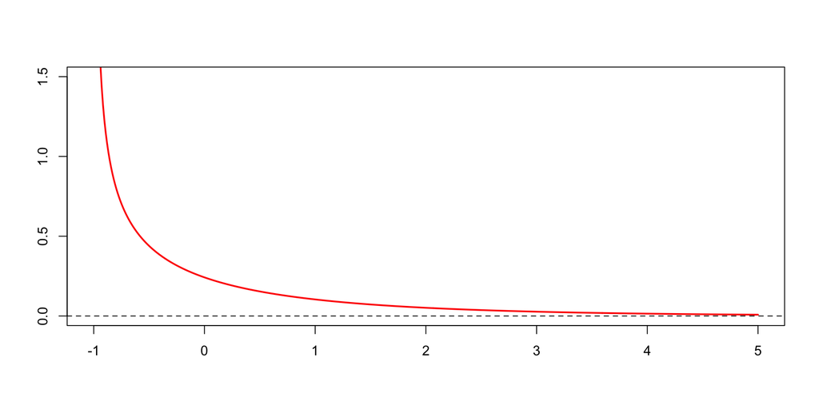

```r
x <- seq(-1, 5, length.out = 500)  # support starts at -1
y <- dchisq(x + 1, df = 1)         # density of χ²(1), shifted

plot(x, y, type = "l", col = "red", lwd = 2,
     main = "", ylab = "", xlab = "", ylim = c(0, 1.5))
abline(h = 0, lty = 2)  # horizontal line at 0
```

The following code took me around 27 minutes and 10 seconds to run (on a 2025 MacBook Pro, 5 minutes slower than David’s “unremarkable 2011 MacBook Pro”).

```r
library(forecast)

reps <- 1000
n <- 200
h <- 12
arv <- c(0.3,0.6,0.9)

Coverage <- matrix(nrow=length(arv), ncol=h)
colnames(Coverage) <- paste0("h=",1:h)
rownames(Coverage) <- paste0("ar=",arv)
CoverageBS <- Coverage
AvgLength <- Coverage
AvgLengthBS <- Coverage

et<- system.time(
for (ac in 1:length(arv)){
  ar <- arv[ac]

  Included <- matrix(nrow=reps, ncol=h)
  IncludedBS <- matrix(nrow=reps, ncol=h)
  Length <- matrix(nrow=reps, ncol=h)
  LengthBS <- matrix(nrow=reps, ncol=h)

  set.seed(3400)
  for (r in 1:reps){

    # Simulate time series
    U <- ((rnorm(n+h))^2-1)/sqrt(2)
    Y <- arima.sim(n=n+h, model=list(ar=ar), innov=U)
    Yf <- Y[(n+1):(n+h)]
    Y <- Y[1:n]

    # AR(1) estimation
    eq <- Arima(Y, order=c(1,0,0))

    # Normal prediction interval
    eqf <- forecast(eq, h=h)
    Lower <- eqf$lower[,"95%"]
    Upper <- eqf$upper[,"95%"]
    Included[r,] <- 1*(Lower<Yf & Upper>Yf)
    Length[r,] <- Upper-Lower

    # Bootstrap prediction interval
    eqf <- forecast(eq, h=h, bootstrap=TRUE)
    LowerBS <- eqf$lower[,"95%"]
    UpperBS <- eqf$upper[,"95%"]
    IncludedBS[r,] <- 1*(LowerBS<Yf & UpperBS>Yf)
    LengthBS[r,] <- UpperBS-LowerBS

  }
  Coverage[ac,] <- apply(Included, 2, mean)*100
  CoverageBS[ac,] <- apply(IncludedBS, 2, mean)*100
  AvgLength[ac,] <- round(apply(Length, 2, mean),2)
  AvgLengthBS[ac,] <- round(apply(LengthBS, 2, mean),2)
})
```

```r
print(Coverage)     # Normal Assumption (Misspecified)
```

```
       h=1  h=2  h=3  h=4  h=5  h=6  h=7  h=8  h=9 h=10 h=11 h=12
ar=0.3  95 94.4 92.8 93.4 94.9 96.0 94.9 95.0 93.3 94.0 94.2 94.7
ar=0.6  94 94.4 94.4 94.2 94.2 94.3 94.3 94.6 95.4 94.3 96.0 95.1
ar=0.9  94 93.9 93.2 94.3 93.0 94.8 93.8 94.4 93.7 94.4 93.2 93.6
```

```r
print(CoverageBS)   # Bootstrapped
```

```
        h=1  h=2  h=3  h=4  h=5  h=6  h=7  h=8  h=9 h=10 h=11 h=12
ar=0.3 94.5 93.3 93.8 93.4 95.5 95.3 94.7 93.4 93.0 94.4 94.5 94.0
ar=0.6 94.3 93.1 93.9 93.9 92.6 92.5 93.2 93.6 94.6 94.0 93.7 92.4
ar=0.9 93.5 92.5 92.2 92.9 92.0 92.9 91.8 92.1 91.3 93.0 92.6 93.4
```

- The coverage results are very similar across the boards.
  - Note: Remember these are just simulation estimates from only 1000 replications, and don’t over-interpret small differences.
- Nevertheless there might be a slight deficiency of about 1% in the coverage of the bootstrap intervals relative to the normal intervals when $\phi=0.9$.
- Otherwise, there is little to choose between the two intervals on this criterion.
  - This is quite interesting because theoretically the bootstrap intervals are valid in this case but the normal intervals are not.
  - Note: CLT does not provide an approximation for non-normal data when computing prediction intervals.

```r
print(AvgLength)    # Normal Assumption (Misspecified)
```

```
        h=1  h=2  h=3  h=4  h=5  h=6  h=7  h=8  h=9 h=10 h=11 h=12
ar=0.3 3.90 4.06 4.08 4.08 4.08 4.08 4.08 4.08 4.08 4.08 4.08 4.08
ar=0.6 3.91 4.54 4.75 4.82 4.85 4.86 4.86 4.87 4.87 4.87 4.87 4.87
ar=0.9 3.91 5.22 6.05 6.64 7.07 7.39 7.64 7.83 7.98 8.10 8.20 8.27
```

```r
print(AvgLengthBS)  # Bootstrapped
```

```
        h=1  h=2  h=3  h=4  h=5  h=6  h=7  h=8  h=9 h=10 h=11 h=12
ar=0.3 3.61 3.81 3.86 3.86 3.87 3.85 3.86 3.87 3.86 3.86 3.86 3.86
ar=0.6 3.62 4.28 4.53 4.63 4.66 4.68 4.69 4.70 4.69 4.69 4.70 4.70
ar=0.9 3.62 4.93 5.80 6.41 6.86 7.19 7.45 7.65 7.82 7.94 8.04 8.13
```

## Exercise 4(a)

Next we well consider the properties of prediction intervals when the normality assumption is not correct. The normal and bootstrap prediction intervals will be compared.

1. The first distribution for $U_t$ is the $\chi_{1}^{2}$ (i.e. chi-squared with 1 degree of freedom) centered to have mean 0.

**Overall:**

- There are not major differences between the two intervals and the choice would be subjective.
- The advantage in length may suggest some *weak preference* for the bootstrap intervals in this particular model.

## Exercise 4(b)

Next we well consider the properties of prediction intervals when the normality assumption is not correct. The normal and bootstrap prediction intervals will be compared.

2. The second distribution for $U_t$ is the $t$ distribution with 4 degrees of freedom.
- True DGP
- Full Code
- Result - Coverage
- Result - Lengths
- Conclusion

The true DGP is:
$$Y_{t}=\phi_{1}Y_{t-1}+U_{t}\quad\textsf{where}\quad \color{blue}{U_{t}\sim t_{4}}$$
This distribution has fatter tails (higher kurtosis) than $\mathrm{N}(0,1)$:

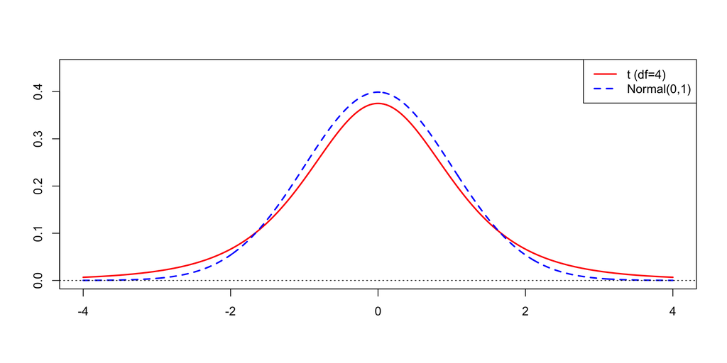

```r
x <- seq(-4, 4, length.out = 1000)
y_t <- dt(x, df = 4)
y_norm <- dnorm(x)

plot(x, y_t, type = "l", col = "red", lwd = 2,
     ylim = c(0, 0.45),
     ylab = "", xlab = "", main = "")
lines(x, y_norm, col = "blue", lty = 2, lwd = 2)
abline(h = 0, lty = 3)
legend("topright", legend = c("t (df=4)", "Normal(0,1)"),
       col = c("red", "blue"), lty = c(1, 2), lwd = 2)
```

```r
library(forecast)

reps <- 1000
n <- 200
h <- 12
arv <- c(0.3,0.6,0.9)

Coverage <- matrix(nrow=length(arv), ncol=h)
colnames(Coverage) <- paste0("h=",1:h)
rownames(Coverage) <- paste0("ar=",arv)
CoverageBS <- Coverage
AvgLength <- Coverage
AvgLengthBS <- Coverage

et<- system.time(
for (ac in 1:length(arv)){
  ar <- arv[ac]

  Included <- matrix(nrow=reps, ncol=h)
  IncludedBS <- matrix(nrow=reps, ncol=h)
  Length <- matrix(nrow=reps, ncol=h)
  LengthBS <- matrix(nrow=reps, ncol=h)

  set.seed(3400)
  for (r in 1:reps){

    # Simulate time series
    U <- rt(n=n+h, df=4)
    Y <- arima.sim(n=n+h, model=list(ar=ar), innov=U)
    Yf <- Y[(n+1):(n+h)]
    Y <- Y[1:n]

    # AR(1) estimation
    eq <- Arima(Y, order=c(1,0,0))

    # Normal prediction interval
    eqf <- forecast(eq, h=h)
    Lower <- eqf$lower[,"95%"]
    Upper <- eqf$upper[,"95%"]
    Included[r,] <- 1*(Lower<Yf & Upper>Yf)
    Length[r,] <- Upper-Lower

    # Bootstrap prediction interval
    eqf <- forecast(eq, h=h, bootstrap=TRUE)
    LowerBS <- eqf$lower[,"95%"]
    UpperBS <- eqf$upper[,"95%"]
    IncludedBS[r,] <- 1*(LowerBS<Yf & UpperBS>Yf)
    LengthBS[r,] <- UpperBS-LowerBS

  }
  Coverage[ac,] <- apply(Included, 2, mean)*100
  CoverageBS[ac,] <- apply(IncludedBS, 2, mean)*100
  AvgLength[ac,] <- round(apply(Length, 2, mean),2)
  AvgLengthBS[ac,] <- round(apply(LengthBS, 2, mean),2)
})
```

```r
print(Coverage)     # Normal Assumption (Misspecified)
```

```
        h=1  h=2  h=3  h=4  h=5  h=6  h=7  h=8  h=9 h=10 h=11 h=12
ar=0.3 94.9 95.0 94.8 94.0 94.6 94.8 93.3 94.0 94.5 94.4 95.9 94.2
ar=0.6 95.2 93.8 94.2 93.6 92.1 94.5 95.2 94.0 94.0 94.9 93.6 93.5
ar=0.9 94.6 95.4 93.7 93.4 93.4 93.4 93.4 91.3 91.5 90.8 91.0 90.8
```

```r
print(CoverageBS)   # Bootstrapped
```

```
        h=1  h=2  h=3  h=4  h=5  h=6  h=7  h=8  h=9 h=10 h=11 h=12
ar=0.3 94.8 94.6 95.0 94.1 94.3 94.8 93.5 94.2 94.3 94.5 95.4 93.6
ar=0.6 95.7 94.3 93.5 93.4 92.5 94.4 95.3 94.2 93.7 94.6 93.3 93.9
ar=0.9 94.2 95.4 93.8 93.7 92.9 93.1 93.0 91.1 91.3 90.2 90.4 90.1
```

**Comments:**

- One finding to note is that the coverage properties deteriorate for larger $h$ when $\phi_{1}=0.9$.
- The finite sample statistical properties of prediction with strong autocorrelation (i.e., large $\phi_{1}$) can require larger samples for the asymptotic properties (i.e. 95% coverage) to apply.

```r
print(AvgLength)    # Normal Assumption (Misspecified)
```

```
        h=1  h=2  h=3  h=4  h=5   h=6   h=7   h=8   h=9  h=10  h=11  h=12
ar=0.3 5.48 5.71 5.73 5.74 5.74  5.74  5.74  5.74  5.74  5.74  5.74  5.74
ar=0.6 5.45 6.32 6.60 6.70 6.74  6.76  6.76  6.76  6.77  6.77  6.77  6.77
ar=0.9 5.52 7.35 8.50 9.31 9.89 10.33 10.66 10.92 11.12 11.28 11.40 11.50
```

```r
print(AvgLengthBS)  # Bootstrapped
```

```
        h=1  h=2  h=3  h=4   h=5   h=6   h=7   h=8   h=9  h=10  h=11  h=12
ar=0.3 5.54 5.77 5.80 5.80  5.79  5.81  5.79  5.80  5.80  5.80  5.80  5.80
ar=0.6 5.56 6.43 6.72 6.81  6.85  6.86  6.87  6.87  6.86  6.85  6.86  6.87
ar=0.9 5.55 7.44 8.64 9.46 10.06 10.56 10.90 11.13 11.33 11.47 11.59 11.69
```

The average lengths of the prediction intervals increases with $h$ and $\phi_{1}$ (the same applied in part a) $\implies$ Long-horizon prediction is more difficult when time series are more strongly autocorrelated.

- Overall, there is no advantage to be found for the bootstrap intervals in this model. If anything they are slightly longer.
- Despite the non-normality, the normal prediction intervals work quite well in this case.
- This could be due to the shape of non-normality is different in this case, as the distribution is symmetric.

Thank you for coming!